# The Analysis on the effect of Severe Weather on Public Health and Economy

Naqeeb Asif

1 February 2018

# 1. Synopsis

Severe weather events bring catastrophe with them. They can be drastic to human lives and can cause great damage to the economy. So it is better to be prepared for the severe weather events beforehand and take extra precautions for the events which do the most damage.  
The aim of this project is to explore U.S. National Oceanic and Atmospheric Administration’s (NOAA) storm database and find out which event causes the most damage to the human lives and economy.  
After analysing the database it was found out that the most damage to the human lives was done by tornadoes and the most damage done to the economy was by the floods.

# 2. Obtaining the data

## 2.1. Data

The data for the anlaysis is in the form of a comma-separated-value file which is compressed via the bzip2 algorithm to reduce its size. The data can be downloaded from the course website: [Storm Data](https://d396qusza40orc.cloudfront.net/repdata%2Fdata%2FStormData.csv.bz2)  
The documentation of the data is also available and can be donwloaded from [National Weather Service Storm Data Documentation](https://d396qusza40orc.cloudfront.net/repdata%2Fpeer2_doc%2Fpd01016005curr.pdf). The answers to some frequently asked questions are also avaible and can be download from [National Climatic Data Center Storm Events FAQ](https://d396qusza40orc.cloudfront.net/repdata%2Fpeer2_doc%2FNCDC%20Storm%20Events-FAQ%20Page.pdf)  
The database contains the recorde from year 1950 to Novemeber 2011. Due to the lack of good records there are fewere events record in many earlier years of the database. The record with the more recents year should be considered more complete.

## 2.2. Loading the required libraries

In this section the libraries required for the whole data are loaded.

```r
library(dplyr)
library(data.table)
library(ggplot2)
library(lubridate)
library(ggstance)
library(grid)
library(gridExtra)
```

## 2.3. Loading the data

The data is first downloaded from the course website. It is then loaded into R.

```r
download.file("https://d396qusza40orc.cloudfront.net/repdata%2Fdata%2FStormData.csv.bz2",
              destfile = "./FStormData.csv.bz2")
weather_data <- data.table(read.csv("./FStormData.csv.bz2"))
```

# 3. Data Processing

This section illustrates the steps performed on the original data to get the required data only.

## 3.1. Data for Analyzing Effects on Population Health

This section illustrates how data for analyzing effects on population health was created. Three columns namely “EVTYPE”,“FATALITIES” and “INJURIES” were selected from the original data. The subset was then grouped by “EVETYPE” and for each event in “EVTYPE” total fatalities and total injuries were calculated and stored in health_data table.

After creating health_data its two subset were created named fatalities_data and injuries_data which contain top10 total fatalities and top10 total injuries respectively.

```r
health_data <- weather_data %>% select(EVTYPE,FATALITIES,INJURIES) %>%
               group_by(EVTYPE) %>% summarise(total_fatalities=sum(FATALITIES),
                                              total_injuries=sum(INJURIES))

fatalities_data <- health_data %>% select(-total_injuries) %>%
                   arrange(desc(total_fatalities)) %>% top_n(10)

injuries_data <- health_data %>% select(-total_fatalities) %>%
                   arrange(desc(total_injuries)) %>% top_n(10)
```

## 3.2. Data for Analyzing effects on Economy

This section illustrates how data for analyzing effects on population health was created. Five columns namely “EVTYPE”,“PROPDMG”,“PROPDMGEXP”,“CROPDMG” and “CROPDMGEXP” were selected from the original data. Two variables were introduced namely property_damge and crop_damage. There values were calculated PROPDMG,PROPDMGEXP and CROPDMG,CROPDMGEXP respectively. The values in PROPDMGEXP and CROPDMG were converted to number using exp_to_number function. Function exp_to_number converts properly according to the values in PROPDMGEXP CROPDMG. The subset of the resultant data is then created using three columns “EVTYPE”,“property_damage” and “crop_damage” which is then group by EVETYPE and for each event in EVTYPE total property damage, total crop damage and total damage are then calculated. The resultant dataset is then stored in the table economy_data.

After creating economy_data its three subset were created named property_data, crop_data and total_ec_data were created which contain top10 total property , top10 total crop and top 10 total damgages respectively.

```r
exp_to_number = function(x){
  v <- rep(0,length(x))
  v[x %in% c("H","h") ] = 10^2
  v[x %in% c("K","k") ] = 10^3
  v[x %in% c("M","m") ] = 10^6
  v[x %in% c("b","B") ] = 10^9

  v
}

economy_data <- weather_data %>% select(EVTYPE,PROPDMG,PROPDMGEXP,CROPDMG,CROPDMGEXP) %>%
                mutate(property_damage = PROPDMG*exp_to_number(PROPDMGEXP),
                       crop_damage = CROPDMG * exp_to_number(CROPDMGEXP)) %>%
                select(EVTYPE,property_damage,crop_damage) %>%
                group_by(EVTYPE) %>%summarise(total_property_dmg = sum(property_damage),
                                            total_crop_dmg=sum(crop_damage)) %>%
                mutate(total_damage=total_property_dmg+total_crop_dmg)

property_data <- economy_data %>% select(EVTYPE,total_property_dmg) %>%
                 arrange(desc(total_property_dmg)) %>%top_n(10)

crop_data <- economy_data %>% select(EVTYPE,total_crop_dmg) %>%
                 arrange(desc(total_crop_dmg)) %>%top_n(10)

total_ec_data <- economy_data %>% select(EVTYPE,total_damage) %>%
                 arrange(desc(total_damage)) %>%top_n(10)
```

# 4. Results

In this section results were produced according to the questions asked.

## 4.1. Imapct on Health

In this section the graph for predicting the imapct of severe weather events on health was plotted.

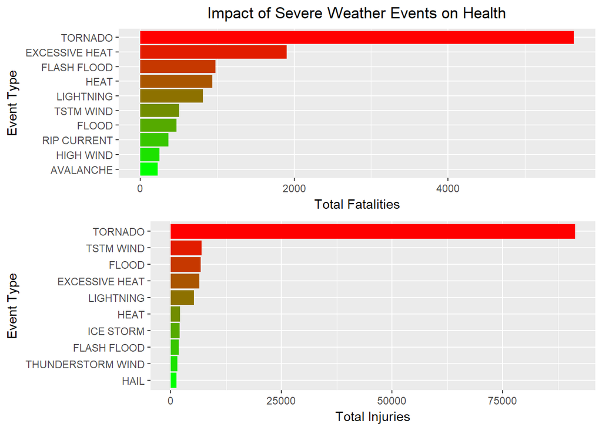

```r
pal <- colorRampPalette(c("green","red"))

g1 <- ggplot(data=fatalities_data,aes(x=reorder(EVTYPE,total_fatalities),y=total_fatalities))+
      geom_bar(stat = "identity",fill=pal(10)) +ylab("Total Fatalities") +xlab("Event Type")+
      theme(plot.title = element_text(hjust = 0.5))+coord_flip() +
      labs(title="Impact of Severe Weather Events on Health")

g2 <- ggplot(data=injuries_data,aes(x=reorder(EVTYPE,total_injuries),y=total_injuries))+
      geom_bar(stat = "identity",fill=pal(10)) +ylab("Total Injuries") +xlab("Event Type")+
      theme(plot.title = element_text(hjust = 0.5))+coord_flip()

grid.arrange(g1,g2,ncol=1)
```

### 4.1.1 Analysis

From the plot it can be seen that tornadoes caused the total fatalities as well as total injuries in U.S.

## 4.2. Impact on Economy

In this section the graph for predicting the imapct of severe weather events on economy was plotted. Two graph were plotted in this section. One graph gives the damage done to property and crops and other graph gives the damage done to the overall economy.

### 4.2.1 Damage done to Property and Crops

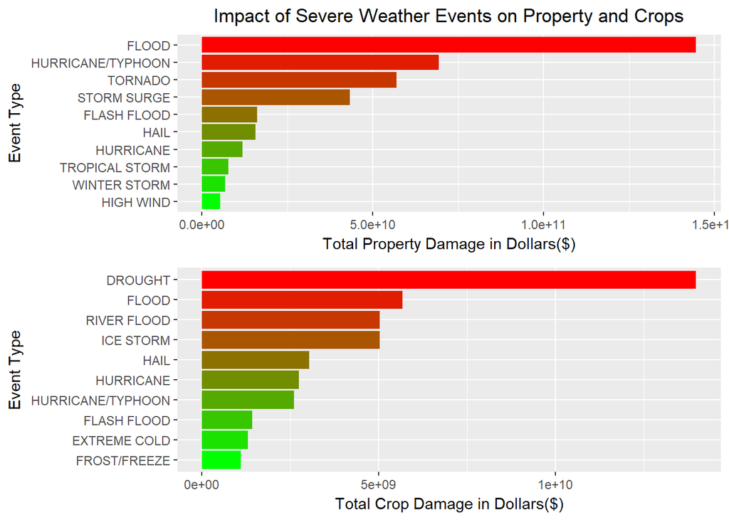

```r
pal <- colorRampPalette(c("green","red"))

p1 <- ggplot(data=property_data,aes(x=reorder(EVTYPE,total_property_dmg),
                                    y=total_property_dmg))+geom_bar(stat = "identity",
                                                                    fill=pal(10)) +
      ylab("Total Property Damage in Dollars($)") +xlab("Event Type")+
      theme(plot.title = element_text(hjust = 0.5))+coord_flip() +
      labs(title="Impact of Severe Weather Events on Property and Crops")

p2 <- ggplot(data=crop_data,aes(x=reorder(EVTYPE,total_crop_dmg),y=total_crop_dmg))+
      geom_bar(stat = "identity",fill=pal(10)) +ylab("Total Crop Damage in Dollars($)") +
      xlab("Event Type")+coord_flip()


grid.arrange(p1,p2,ncol=1)
```

### 4.2.2 Damage done to Overall Economy

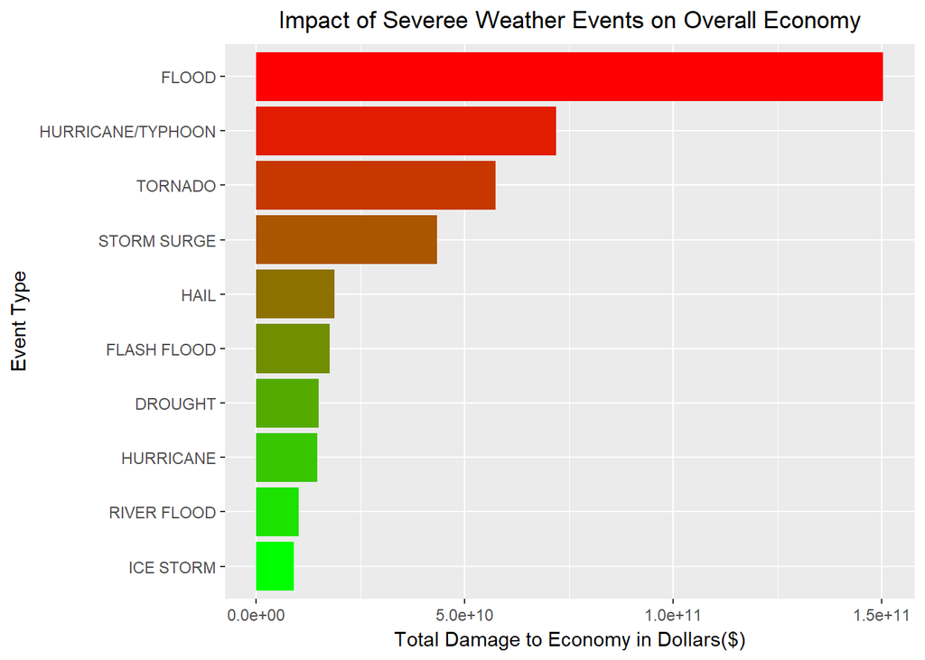

```r
p3 <- ggplot(data=total_ec_data,aes(x=reorder(EVTYPE,total_damage),y=total_damage))+
      geom_bar(stat = "identity",fill=pal(10)) +ylab("Total Damage to Economy in Dollars($)") +
      xlab("Event Type")+theme(plot.title = element_text(hjust = 0.5))+coord_flip() +
      labs(title="Impact of Severee Weather Events on Overall Economy")

p3
```

### 4.2.3 Analysis

From the plot it can be seen floods caused the most damage to the property and drought caused the most damage to the crops. Overall the floods caused the most damage to the economy.

# 5. Conclusion

From the results it can be concluded that the toranado caused the most damage to the injuries and people lives i.e. tornadoes impacted the human lives the most in United States. Wheras the floods casued the most damage to the property and draughts caused the most damage to the crops. Overall floods impacted the economy the most in United States.